# loans

# Read the file and understand more about the dataset

```r
loans<-read.csv("loans.csv")
summary(loans)
```

```
 credit.policy                 purpose        int.rate       installment
 Min.   :0.000   all_other         :2331   Min.   :0.0600   Min.   : 15.67
 1st Qu.:1.000   credit_card       :1262   1st Qu.:0.1039   1st Qu.:163.77
 Median :1.000   debt_consolidation:3957   Median :0.1221   Median :268.95
 Mean   :0.805   educational       : 343   Mean   :0.1226   Mean   :319.09
 3rd Qu.:1.000   home_improvement  : 629   3rd Qu.:0.1407   3rd Qu.:432.76
 Max.   :1.000   major_purchase    : 437   Max.   :0.2164   Max.   :940.14
                 small_business    : 619
 log.annual.inc        dti              fico       days.with.cr.line
 Min.   : 7.548   Min.   : 0.000   Min.   :612.0   Min.   :  179
 1st Qu.:10.558   1st Qu.: 7.213   1st Qu.:682.0   1st Qu.: 2820
 Median :10.928   Median :12.665   Median :707.0   Median : 4140
 Mean   :10.932   Mean   :12.607   Mean   :710.8   Mean   : 4562
 3rd Qu.:11.290   3rd Qu.:17.950   3rd Qu.:737.0   3rd Qu.: 5730
 Max.   :14.528   Max.   :29.960   Max.   :827.0   Max.   :17640
 NA's   :4                                         NA's   :29
   revol.bal         revol.util     inq.last.6mths    delinq.2yrs
 Min.   :      0   Min.   :  0.00   Min.   : 0.000   Min.   : 0.0000
 1st Qu.:   3187   1st Qu.: 22.70   1st Qu.: 0.000   1st Qu.: 0.0000
 Median :   8596   Median : 46.40   Median : 1.000   Median : 0.0000
 Mean   :  16914   Mean   : 46.87   Mean   : 1.572   Mean   : 0.1638
 3rd Qu.:  18250   3rd Qu.: 71.00   3rd Qu.: 2.000   3rd Qu.: 0.0000
 Max.   :1207359   Max.   :119.00   Max.   :33.000   Max.   :13.0000
                   NA's   :62       NA's   :29       NA's   :29
    pub.rec       not.fully.paid
 Min.   :0.0000   Min.   :0.0000
 1st Qu.:0.0000   1st Qu.:0.0000
 Median :0.0000   Median :0.0000
 Mean   :0.0621   Mean   :0.1601
 3rd Qu.:0.0000   3rd Qu.:0.0000
 Max.   :5.0000   Max.   :1.0000
 NA's   :29
```

```r
str(loans)
```

```
'data.frame':   9578 obs. of  14 variables:
 $ credit.policy    : int  1 1 1 1 1 1 1 1 1 1 ...
 $ purpose          : Factor w/ 7 levels "all_other","credit_card",..: 3 2 3 3 2 2 3 1 5 3 ...
 $ int.rate         : num  0.119 0.107 0.136 0.101 0.143 ...
 $ installment      : num  829 228 367 162 103 ...
 $ log.annual.inc   : num  11.4 11.1 10.4 11.4 11.3 ...
 $ dti              : num  19.5 14.3 11.6 8.1 15 ...
 $ fico             : int  737 707 682 712 667 727 667 722 682 707 ...
 $ days.with.cr.line: num  5640 2760 4710 2700 4066 ...
 $ revol.bal        : int  28854 33623 3511 33667 4740 50807 3839 24220 69909 5630 ...
 $ revol.util       : num  52.1 76.7 25.6 73.2 39.5 51 76.8 68.6 51.1 23 ...
 $ inq.last.6mths   : int  0 0 1 1 0 0 0 0 1 1 ...
 $ delinq.2yrs      : int  0 0 0 0 1 0 0 0 0 0 ...
 $ pub.rec          : int  0 0 0 0 0 0 1 0 0 0 ...
 $ not.fully.paid   : int  0 0 0 0 0 0 1 1 0 0 ...
```

# Understand the proportion of loans that are not fully paid

```r
mytable<-with(loans,table(not.fully.paid))
prop.table(mytable)
```

```
not.fully.paid
        0         1
0.8399457 0.1600543
```

# Remove rows with missing values using complete.cases function

Also take a proportion of loans not fully paid after cleaning Here, the code is made not to execute as imputations done in the next R block will take care of the missing values If you want to execute this block, change the value of T to 1

```r
T=2
if (T==1){
  nrow(loans)
  loans_complete<-complete.cases(loans)
  nrow(loans[loans_complete,])
  mtable2<-with(loans[loans_complete,],table(not.fully.paid))
  prop.table(mtable2)
}
```

# Imputations

Another way to account of missing values. The idea is you complete missing values using some heuristic choices. A common way to remember this is replace missing values with mean of the column. mice is a package that is used for imputations Here we want to impute missing values. We set vars.for.imputation to all variables in the data frame except for not.fully.paid, to impute the values using all of the other independent variables.

```r
library(mice)
set.seed(144)
#We set vars.for.imputation to all variables in the data frame except for not.fully.paid, to impute the values using all of the other independent variables.
vars.for.imputation = setdiff(names(loans), "not.fully.paid")
imputed = complete(mice(loans[vars.for.imputation]))
loans[vars.for.imputation] = imputed
```

# Split the dataset by not.fully.paid column.

70% of the rows got in the training data set and remaining in the test set

```r
# Just in case the OS has created a different version based on mice, let us use a dataset to make
# sure that results are same as the remaining class
#loans<-read.csv("loans_imputed.csv")
library(caTools)
set.seed(144)
split = sample.split(loans$not.fully.paid, SplitRatio = 0.7)
train = subset(loans, split == TRUE)
test = subset(loans, split == FALSE)
```

# Build the first logistic regression model

Remember “purpose” is a categorical variable. So, all the values for purpose show up as variables in the model. They need to be interpreted with respect to the first value in the purpose variable i.e. purpose == 1

So, for the regression output below, when purpose==2, the log of odds ratio is 0.61 less than that with purpose==1. The coefficient of purpose==1 will be the intercept

The actual values of purpose can be found by executing levels(train$purpose) command. The numbers are in the same order as the output of the above command

```r
loansmodel1=glm(not.fully.paid~.
                ,data=train,family="binomial")
summary(loansmodel1)
```

```
Call:
glm(formula = not.fully.paid ~ ., family = "binomial", data = train)

Deviance Residuals:
    Min       1Q   Median       3Q      Max
-2.2097  -0.6214  -0.4950  -0.3601   2.6414

Coefficients:
                    Estimate Std. Error z value Pr(>|z|)
(Intercept)        9.260e+00  1.554e+00   5.958 2.55e-09 ***
credit.policy     -3.327e-01  1.011e-01  -3.292 0.000995 ***
purpose2          -6.100e-01  1.344e-01  -4.538 5.67e-06 ***
purpose3          -3.181e-01  9.185e-02  -3.463 0.000534 ***
purpose4           1.386e-01  1.753e-01   0.791 0.429074
purpose5           1.774e-01  1.479e-01   1.199 0.230496
purpose6          -4.783e-01  2.009e-01  -2.381 0.017260 *
purpose7           4.159e-01  1.419e-01   2.932 0.003373 **
int.rate           6.202e-01  2.085e+00   0.297 0.766111
installment        1.279e-03  2.093e-04   6.110 9.96e-10 ***
log.annual.inc    -4.357e-01  7.151e-02  -6.093 1.11e-09 ***
dti                4.733e-03  5.501e-03   0.861 0.389508
fico              -9.406e-03  1.707e-03  -5.510 3.60e-08 ***
days.with.cr.line  3.174e-06  1.587e-05   0.200 0.841463
revol.bal          3.103e-06  1.169e-06   2.653 0.007966 **
revol.util         1.796e-03  1.532e-03   1.172 0.241022
inq.last.6mths     8.386e-02  1.577e-02   5.317 1.06e-07 ***
delinq.2yrs       -7.794e-02  6.532e-02  -1.193 0.232814
pub.rec            3.191e-01  1.134e-01   2.814 0.004899 **
---
Signif. codes:  0 *** 0.001 ** 0.01 * 0.05 . 0.1   1

(Dispersion parameter for binomial family taken to be 1)

    Null deviance: 5896.6  on 6704  degrees of freedom
Residual deviance: 5485.7  on 6686  degrees of freedom
AIC: 5523.7

Number of Fisher Scoring iterations: 5
```

```r
# A and B are identical, except for the FICO scores. A's FICO score is 700 and B's is 710
# FICO coefficient = -9.317e-03
# odd(A)/odd(B) = exp(-9.317e-03*700)/exp(-9.317e-03*710)
# Test set predictions
```

# Evaluate the model

Evaluate the model and calculate accuracy of the model

```r
test$predicted.risk = predict(loansmodel1, newdata=test, type="response")
```

```
contrasts dropped from factor purpose
```

```r
table(test$not.fully.paid,test$predicted.risk>=0.5)
```

```
    FALSE TRUE
  0  2400   13
  1   457    3
```

```r
#  FALSE TRUE
#0  2400   13
#1   457    3
# accuracy = 2403/2873
# baseline accuracy
table(test$not.fully.paid)
```

```
   0    1
2413  460
```

```r
#    0    1
# 2413  460
# baseline accuracy = 2413/2873
```

# Get AUC of the model

```r
library("ROCR")
ROCRpred = prediction(test$predicted.risk, test$not.fully.paid)
as.numeric(performance(ROCRpred, "auc")@y.values)
```

```
[1] 0.6721337
```

# Get out-of-sample AUC of the model

Out of sample AUC is 62%

```r
loansmodel2=glm(not.fully.paid~int.rate,data=train,family="binomial")
summary(loansmodel2)
```

```
Call:
glm(formula = not.fully.paid ~ int.rate, family = "binomial",
    data = train)

Deviance Residuals:
    Min       1Q   Median       3Q      Max
-1.0547  -0.6271  -0.5442  -0.4361   2.2914

Coefficients:
            Estimate Std. Error z value Pr(>|z|)
(Intercept)  -3.6726     0.1688  -21.76   <2e-16 ***
int.rate     15.9214     1.2702   12.54   <2e-16 ***
---
Signif. codes:  0 *** 0.001 ** 0.01 * 0.05 . 0.1   1

(Dispersion parameter for binomial family taken to be 1)

    Null deviance: 5896.6  on 6704  degrees of freedom
Residual deviance: 5734.8  on 6703  degrees of freedom
AIC: 5738.8

Number of Fisher Scoring iterations: 4
```

```r
testPrediction = predict(loansmodel2, newdata=test, type="response")
max(testPrediction)
```

```
[1] 0.426624
```

```r
table(test$not.fully.paid,testPrediction>=0.5)
```

```
    FALSE
  0  2413
  1   460
```

```r
ROCRpred = prediction(testPrediction, test$not.fully.paid)
as.numeric(performance(ROCRpred, "auc")@y.values)
```

```
[1] 0.6239081
```

# Plot the ROCR curve

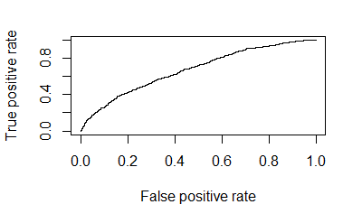

```r
# Performance function
ROCRperfLog = performance(ROCRpred, "tpr", "fpr")
# Plot ROC curve
plot(ROCRperfLog)
```

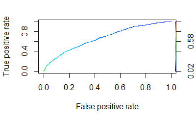

```r
# Add colors
plot(ROCRperfLog, colorize=TRUE)
```